# Abandon the rainbows?

acarioli

13/08/2018

Are rainbow palettes really that bad? If it depended on me, my ideal color palettes would be the color of my favorite toy as a kid: fluo squishy slime, the kind that lights up in the dark. However, not everyone appreciates it, especially scientific journals. In the end, the presence of colors should be motivated by what’s being represented: a cluster of lines depicting the TFR trends in every country in the world during the past century would not benefit from a 250 colors scale. However, it’s different for maps and heatmaps as the right palette can improve the message, condensing and directing information (see this https://ikashnitsky.github.io/2018/the-lancet-paper/). Rainbow palettes work however rather well (in my opinion) in some instances (https://wordpress.com/view/aledemogr.com) although they can easily be substituted with less catchy and more printer friendly colors.

I have downloaded the json file from https://toyokeizai.net/sp/visual/tko/temperature/ and transformed it into a dataframe using the rjson package. I have used a bunch of color palettes to compare results. Eversince discovering the viridis palettes, I am a huge fan of the ‘magma’ and ‘inferno’ as their darkest color is a deep black and it’s easier to highlight everything else.

Reds palette:

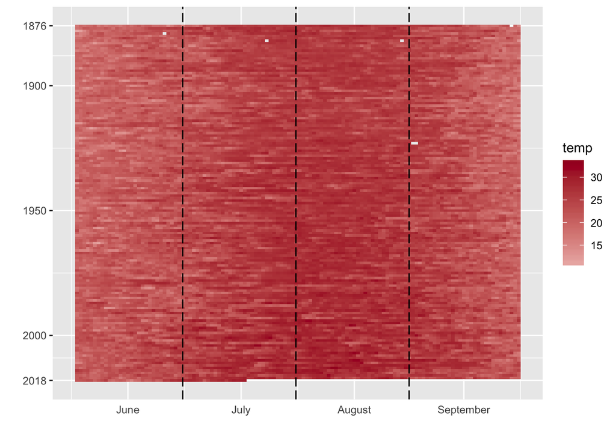

Red-yellow-green palette:

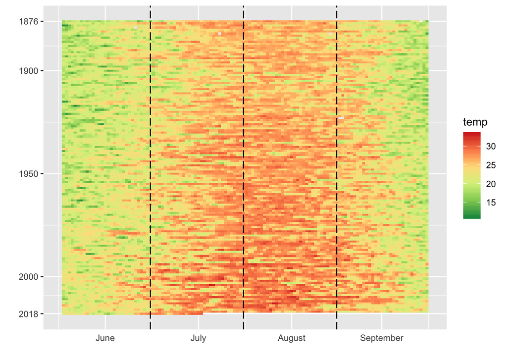

Red-purple palette:

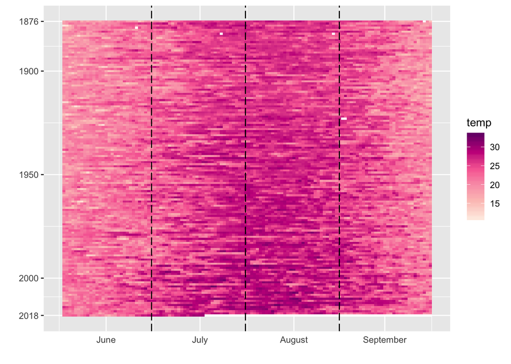

Rainbow palette:

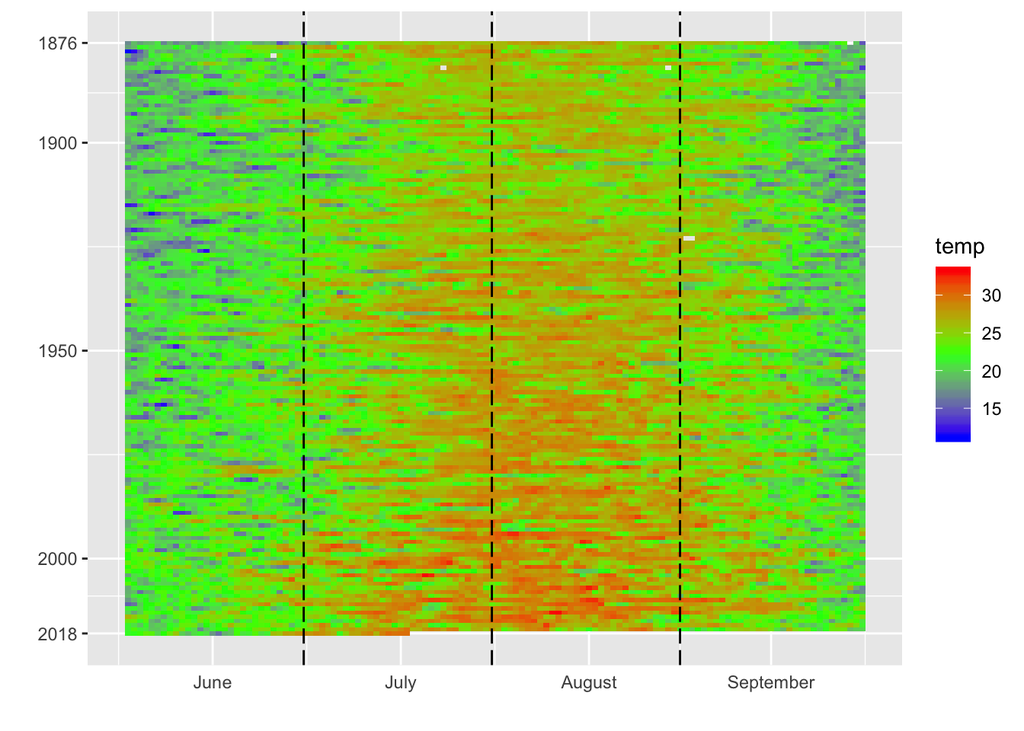

Magma palette:

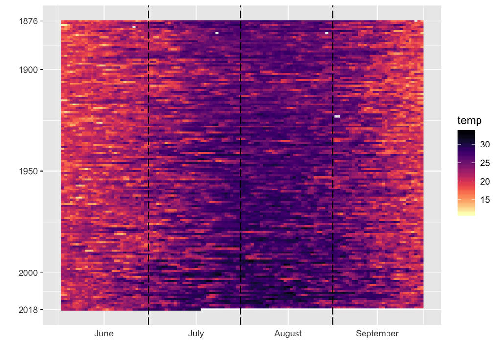

Inferno palette:

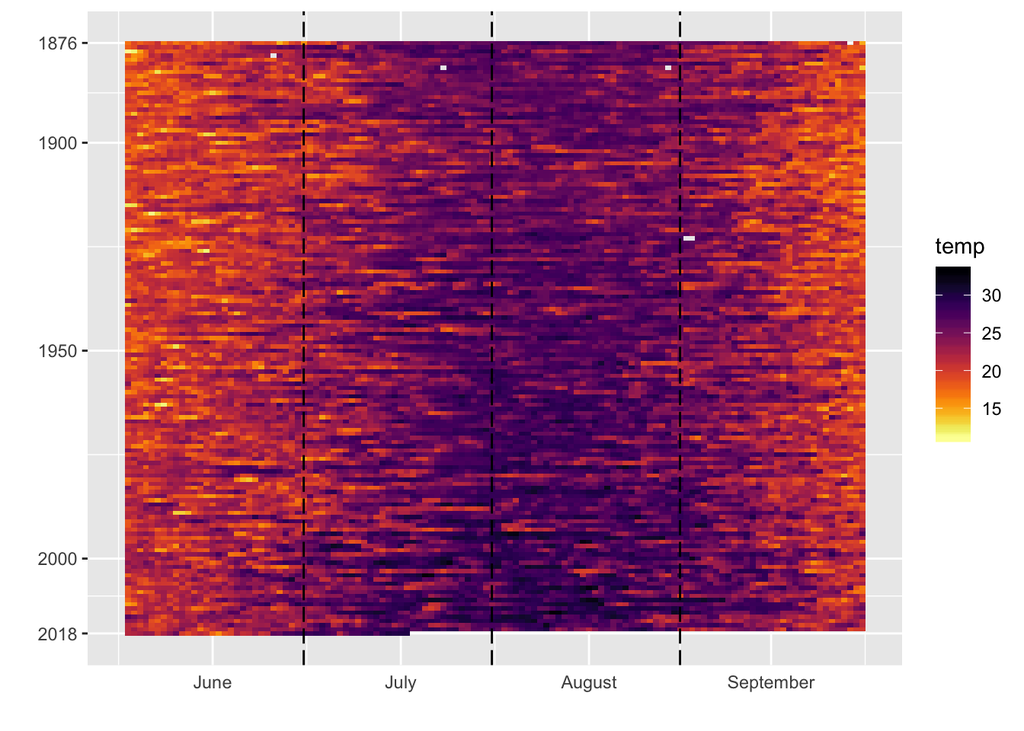

Plasma palette:

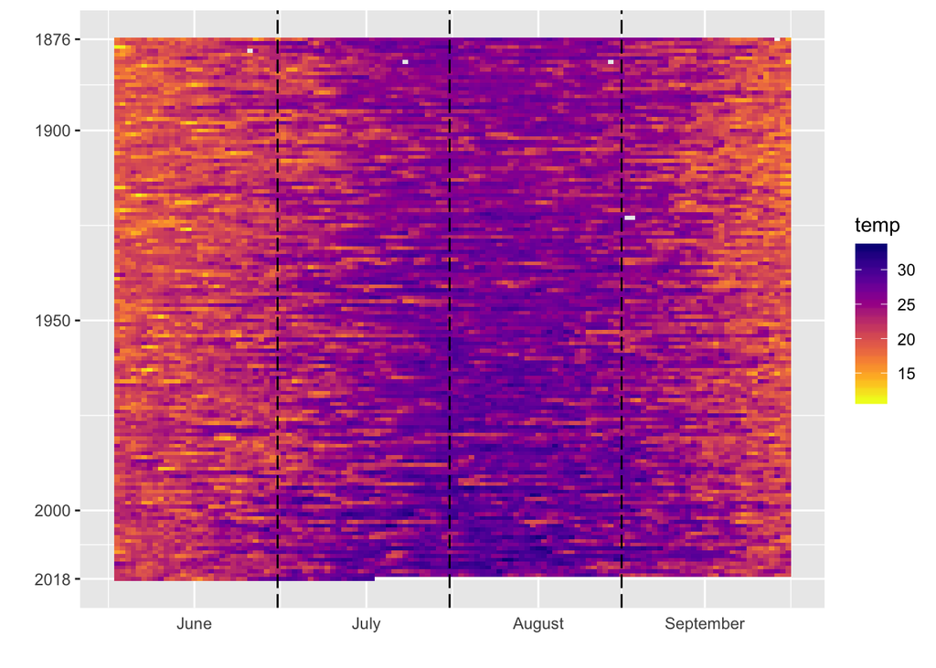

Viridis palette:

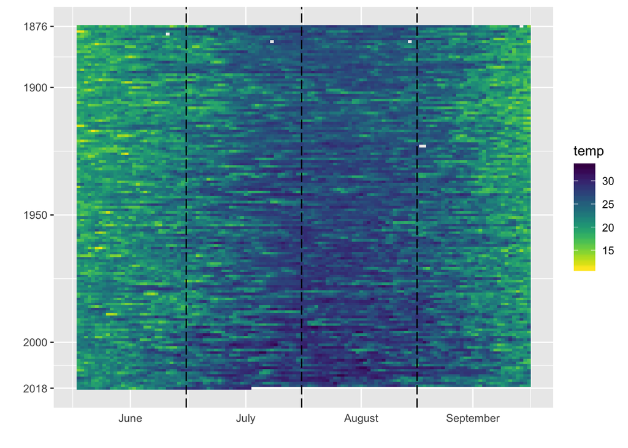

Cividis palette:

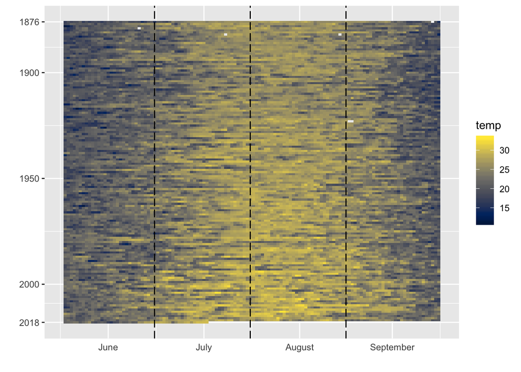

```r
ggplot(dt, aes(order, year))+
  geom_tile(aes(fill = temp)) +
  scale_fill_cividis(na.value = "transparent")+
  scale_y_reverse(name='', breaks = c(1876, 1900, 1950, 2000, 2018), labels=c('1876', '1900', '1950', '2000', '2018'))+
  scale_x_continuous(name='', breaks = c(30-15, 61-15, 92-15, 122-15), labels=c('June', 'July', 'August', 'September'))+
  theme(axis.ticks.x = element_blank())+
  geom_vline(xintercept=c(30, 61, 92), linetype = "longdash" )
```

Greys palette:

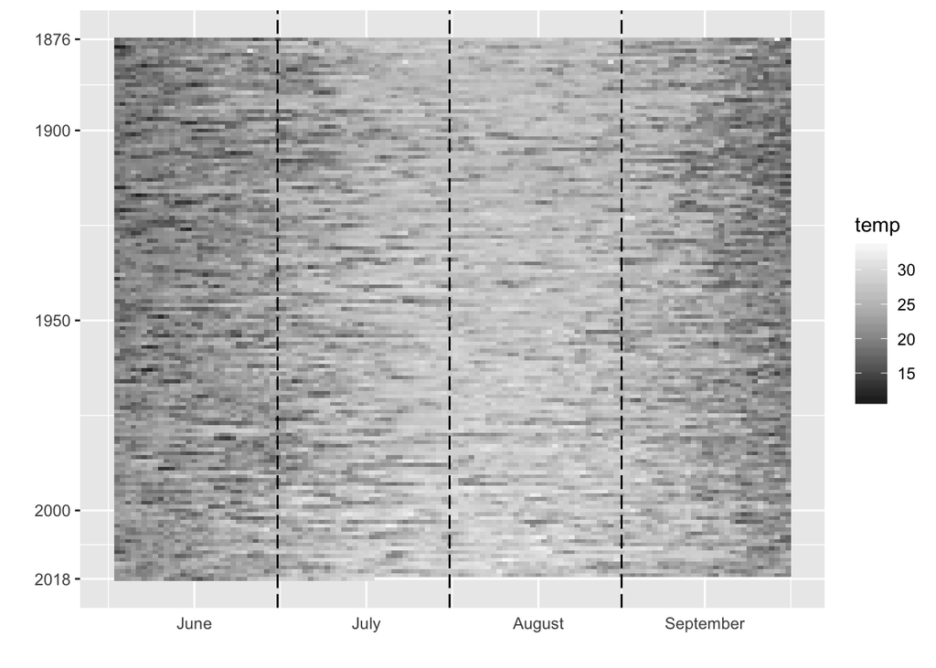

Inverted grey palette:

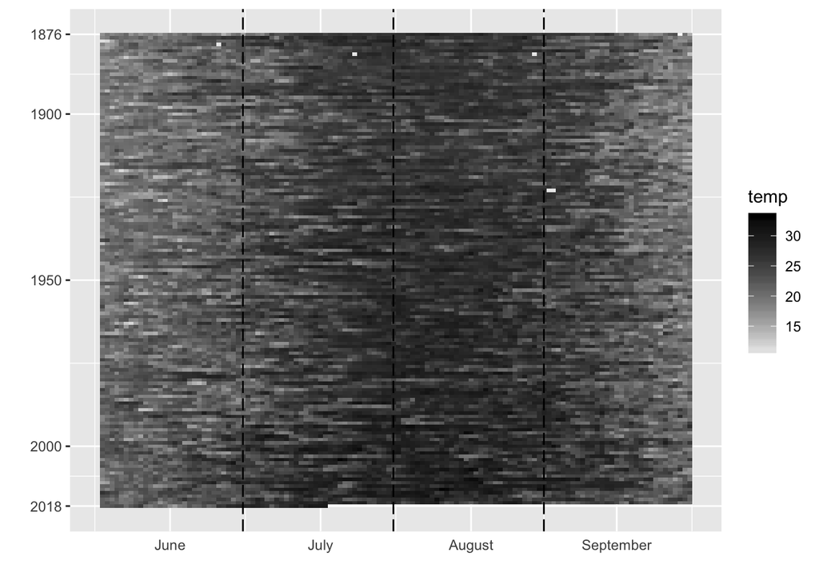